# Carbon Chemestry explore

Ana Palacio-Castro

2021-07-22

# Import and format carbon chemestry data

# 1. Data available

## Number of samples

### By year and region

| Region | 2012 | 2013 | 2014 | 2015 | 2016 | 2017 | 2018 | 2019 |
| --- | --- | --- | --- | --- | --- | --- | --- | --- |
| FLK | 115 | 71 | 135 | 183 | 421 | 388 | 353 | 235 |
| FGB | NA | 22 | NA | 23 | NA | NA | 17 | 14 |
| USVI | NA | 70 | NA | 98 | NA | 90 | NA | NA |
| DRTO | NA | NA | 60 | NA | 43 | NA | 68 | NA |
| PR | NA | NA | 80 | NA | 71 | NA | NA | 28 |
| SEFCRI | NA | NA | NA | NA | NA | NA | 48 | NA |

### By season and region

| Region | Fall | Spring | Summer | Winter |
| --- | --- | --- | --- | --- |
| FGB | 22 | NA | 54 | NA |
| FLK | 444 | 500 | 542 | 415 |
| PR | 39 | 10 | 124 | 6 |
| SEFCRI | 48 | NA | NA | NA |
| STX | 20 | NA | 44 | NA |
| DRTO | NA | 24 | 147 | NA |

## Number of sites per region

Florida Keys

| Year | SiteID | n |
| --- | --- | --- |
| 2012 | ADCP 2 | 1 |
| 2012 | ADCP N | 2 |
| 2012 | ADCP NE | 9 |
| 2012 | ADCP NE | 5 |
| 2012 | ADCP S | 12 |
| 2012 | ADCP SW | 3 |
| 2012 | ADCP2 | 1 |
| 2012 | ADCP3 | 3 |
| 2012 | Cal Val N | 19 |
| 2012 | Cal Val S | 17 |

[output cut: 265 more lines]

| SiteID | 2012 | 2013 | 2014 | 2015 | 2016 | 2017 | 2018 | 2019 |
| --- | --- | --- | --- | --- | --- | --- | --- | --- |
| ADCP 2 | 1 | NA | NA | NA | NA | NA | NA | NA |
| ADCP N | 2 | NA | NA | NA | NA | NA | NA | NA |
| ADCP NE | 9 | 6 | 19 | 21 | 20 | 21 | 22 | 22 |
| ADCP NE | 5 | 1 | NA | NA | 1 | 2 | NA | NA |
| ADCP S | 12 | 8 | 19 | 21 | 22 | 21 | 22 | 21 |
| ADCP SW | 3 | NA | NA | NA | NA | NA | NA | NA |

**Note:** This looks like the original data were the SiteIDs are not curated :(

Puerto Rico

| Year | SiteID | n |
| --- | --- | --- |
| 2014 | 104 | 1 |
| 2014 | 105 | 1 |
| 2014 | 106 | 1 |
| 2014 | 108 | 1 |
| 2014 | 11 | 1 |
| 2014 | 119 | 1 |
| 2014 | 121 | 1 |
| 2014 | 125 | 1 |
| 2014 | 127 | 1 |
| 2014 | 132 | 1 |

[output cut: 169 more lines]

| SiteID | 2014 | 2016 | 2019 |
| --- | --- | --- | --- |
| 104 | 1 | NA | NA |
| 105 | 1 | NA | NA |
| 106 | 1 | NA | NA |
| 108 | 1 | NA | NA |
| 11 | 1 | NA | NA |
| 119 | 1 | NA | NA |

**Note:** Each sample has an unique SiteID?

# 2. Basic stats summary

## Temperature

| Region | Season | Tmin | Tmax | Tmean | Tsd |
| --- | --- | --- | --- | --- | --- |
| DRTO | Spring | 25.40 | 28.1 | 26.37083 | 0.7315732 |
| DRTO | Summer | 26.00 | 32.4 | 29.26558 | 1.4173978 |
| FGB | Fall | 29.50 | 31.6 | 30.08182 | 0.4031263 |
| FGB | Summer | 27.44 | 30.4 | 28.92481 | 0.7795856 |
| FLK | Fall | 22.30 | 38.8 | 28.44561 | 2.5398606 |
| FLK | Spring | 22.04 | 30.3 | 26.00514 | 1.6112156 |

## Aragonite

```r
Aragonite.Season <- ddply (CC.data, .(Region, Season),summarise,
                Amin = min (Aragonite_Sat_W, na.rm = F),
                Amax = max (Aragonite_Sat_W, na.rm = F),
                Amean = mean (Aragonite_Sat_W, na.rm = F),
                Asd = sd (Aragonite_Sat_W, na.rm = F))

kable(head(Aragonite.Season, format = "html"))
```

| Region | Season | Amin | Amax | Amean | Asd |
| --- | --- | --- | --- | --- | --- |
| DRTO | Spring | 2.939 | 3.770 | 3.582000 | 0.1675797 |
| DRTO | Summer | 3.376 | 4.770 | 3.828306 | 0.1753881 |
| FGB | Fall | 3.590 | 4.160 | 4.039091 | 0.1158369 |
| FGB | Summer | 2.886 | 4.049 | 3.760241 | 0.2805205 |
| FLK | Fall | 2.152 | 4.339 | 3.510937 | 0.3890500 |
| FLK | Spring | NA | NA | NA | NA |

## TA

```r
TA.Season <- ddply (CC.data, .(Region, Season),summarise,
                TAmin = min (TA, na.rm = F),
                TAmax = max (TA, na.rm = F),
                TAmean = mean (TA, na.rm = F),
                TAsd = sd (TA, na.rm = F))

kable(head(TA.Season, format = "html"))
```

| Region | Season | TAmin | TAmax | TAmean | TAsd |
| --- | --- | --- | --- | --- | --- |
| DRTO | Spring | 2323.62 | 2408.45 | 2384.557 | 22.966315 |
| DRTO | Summer | 2320.90 | 2417.21 | 2386.605 | 14.140407 |
| FGB | Fall | 2400.67 | 2411.70 | 2406.100 | 3.228101 |
| FGB | Summer | 2336.79 | 2423.90 | 2394.056 | 22.963883 |
| FLK | Fall | 2123.50 | 2527.00 | 2379.794 | 51.286398 |
| FLK | Spring | 2118.04 | 2504.03 | 2366.636 | 49.111064 |

## DIC

```r
DIC.Season <- ddply (CC.data, .(Region, Season),summarise,
                Amin = min (DIC, na.rm = F),
                Amax = max (DIC, na.rm = F),
                Amean = mean (DIC, na.rm = F),
                Asd = sd (DIC, na.rm = F))

kable(head(DIC.Season, format = "html"))
```

| Region | Season | Amin | Amax | Amean | Asd |
| --- | --- | --- | --- | --- | --- |
| DRTO | Spring | 1985.25 | 2098.96 | 2066.219 | 28.158950 |
| DRTO | Summer | 1928.57 | 2089.50 | 2051.155 | 17.624010 |
| FGB | Fall | 2042.36 | 2088.90 | 2049.352 | 9.522669 |
| FGB | Summer | 2034.54 | 2114.88 | 2070.250 | 15.887345 |
| FLK | Fall | 1797.42 | 2295.58 | 2077.074 | 69.473221 |
| FLK | Spring | NA | NA | NA | NA |

**Note:** What is limit for the seasons that makes more sense (now jus using months)?. Wet vs dry/ temoerature/light

# Explore plots

## Aragonite overview

### Sites

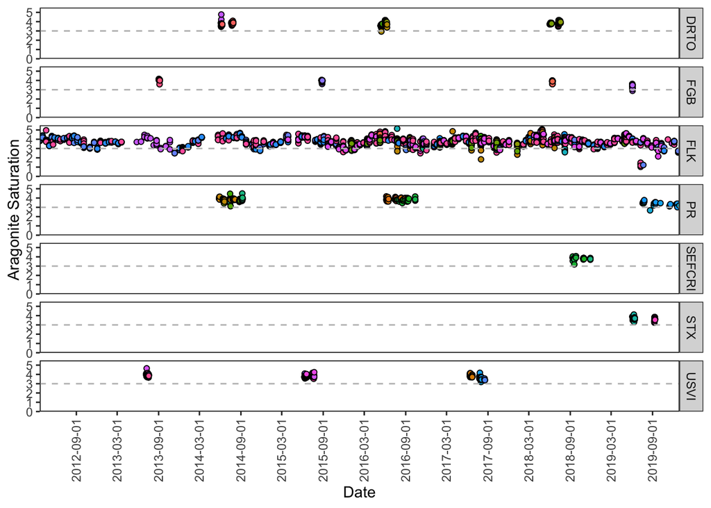

What is the meaning of the sites?

### Seasons

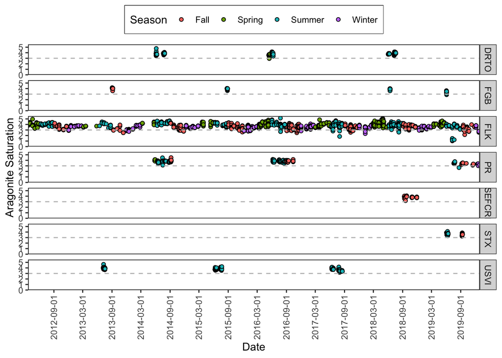

## Temperature overview

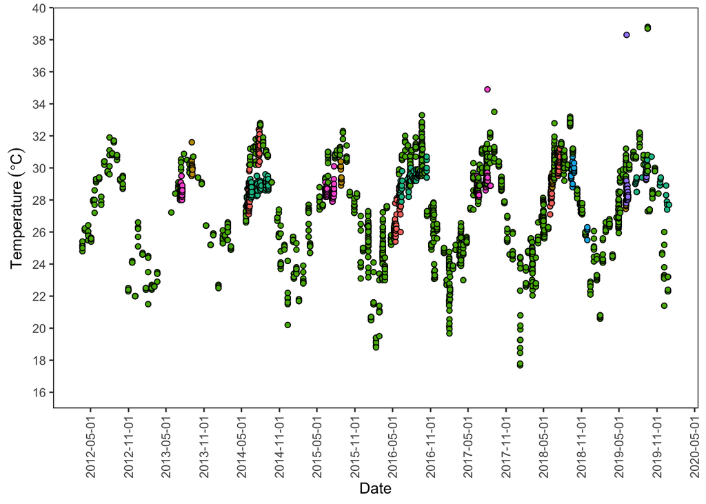

**Note:** Are the 38+ data points real?

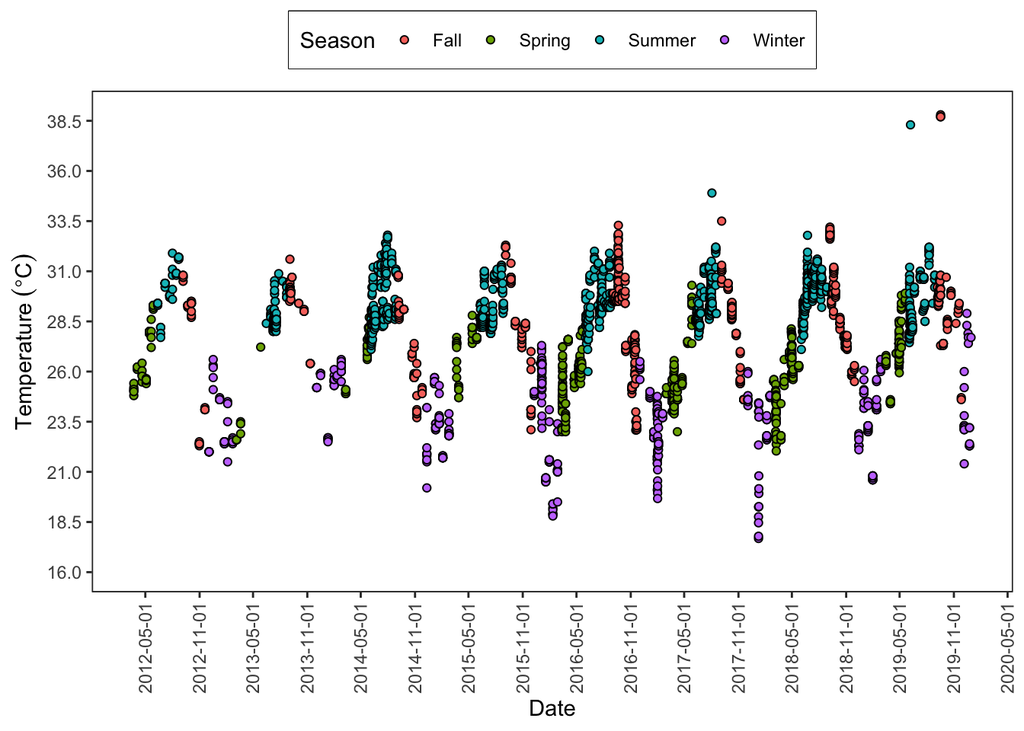

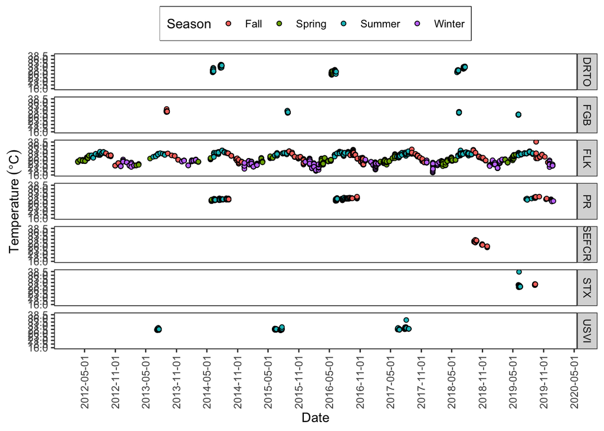

## Salinity overview

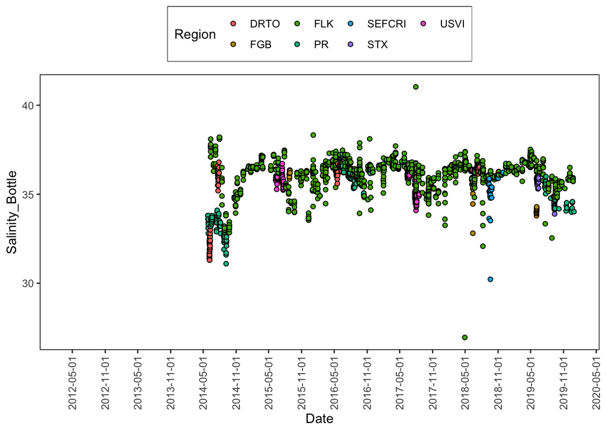

**Note:** Are the 38+ data points real?

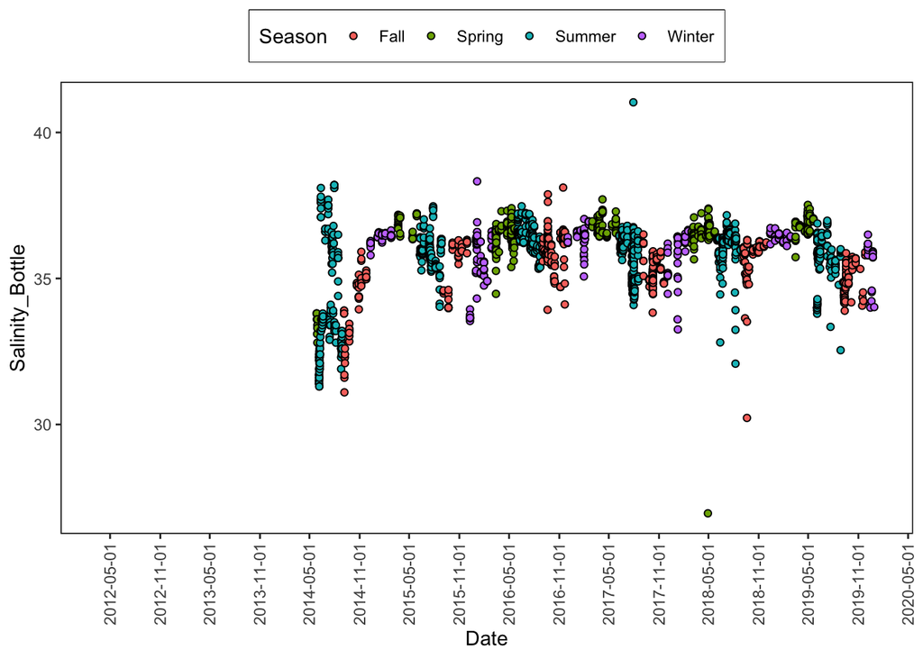

## Correlations to check outliers

Temperature and Arg

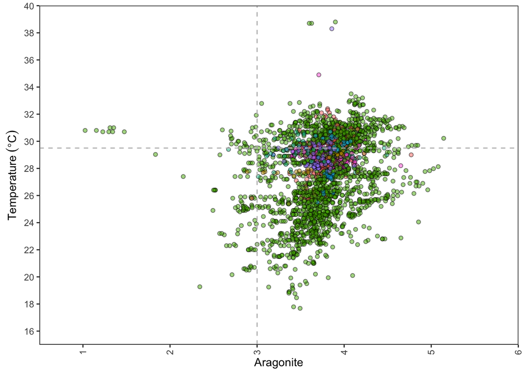

TA and DIC

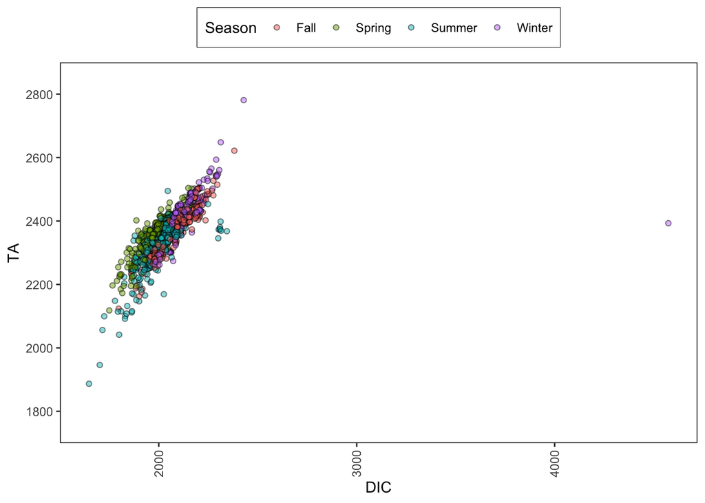

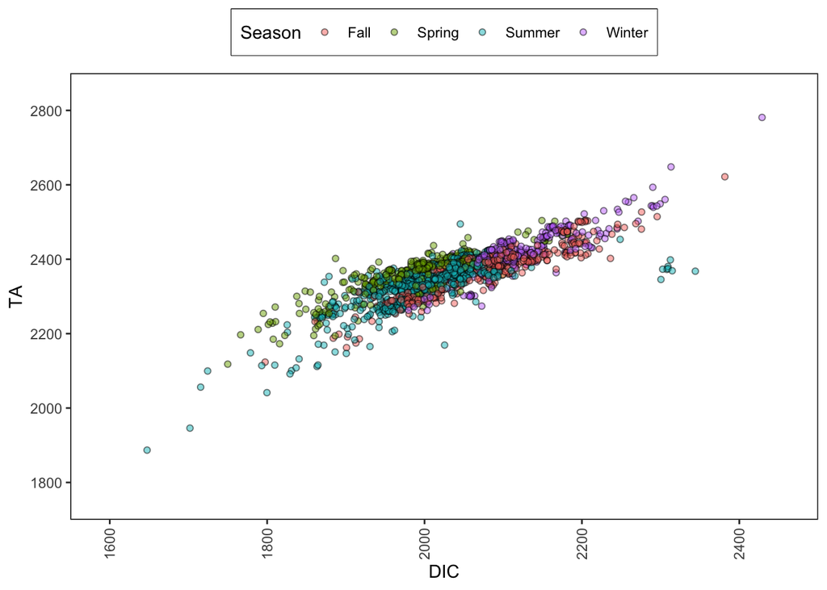

```r
Relationships2 + scale_x_continuous(name="DIC",
                  limits = c(1550, 2500),
                  expand = c(0, 0),
                  breaks = seq(1600,2500,200))
```

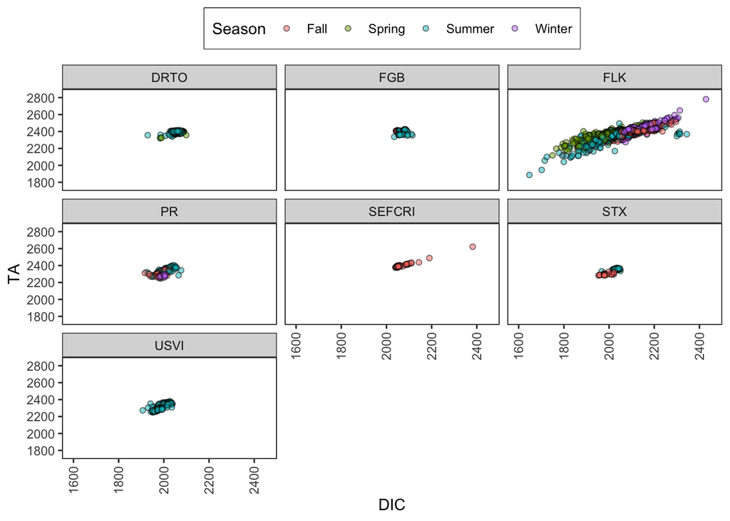

```r
Relationships2 + scale_x_continuous(name="DIC",
                  limits = c(1550, 2500),
                  expand = c(0, 0),
                  breaks = seq(1600,2500,200))+
  facet_wrap(~Region)
```

# 3. Notes/ideas

- Regional CC
- local carbonate chemistry:
  - Seasonal (light), storms, upwelling, salinity (rain). *Biological: coral/seagrass/macroalgae cover
  - Biological + Seasonal: Photosyntesis, respiration.
  - Physical: inlets, rivers, upwelling

## Manzello (2012)

- local carbonate chemistry: Variation on CO2, alkalinity, and salinity - Florida Reef Tract (FRT) data.
- Meassure total CO2 (TCO2) - coulometrically and total alkalinity (TA) - gran titration. Other paramethers derived
- Predominantly in inshore / upper FRT (higher than modeled).
- H Productivity -> net uptake of total CO2 (TCO2) -> H aragonite *Offshore reefs: oceanic carbonate chemistries consistent with present day tropical surface ocean conditions.
- Photosynthetic uptake of TCO2 by seagrasses/macroalgae in the inshore waters of the FRT. Acidification refugia (spatial * time)

## Uthicke (2014)

- GBR - 14 Inshore fringing reefs Meassured: TA and DIC. Derived:pCO2, pH and aragonite
- TA: 2069 - 2364 mmol kg2
- DIC:1846 - 2099 mmol kg2
- pCO2: 340 - 554 matm
  - Higher wet seasons
  - Inshore reefs above atmospheric values.
  - Arg was not further reduced in the wet season (temp effects) *Thermodynamic effects and anthropogenic runoff (P, R and P/R ratios).
  - Expected slope of linear regression bw DIC and TA in systems where calcification is dominating is ~ 2.0

## Cyronak (2018)

- Net community production; NCP - organic
- net community calcification; NCC inorganic
- 23 coral reef locations across the globe - derived from TA and DIC
- All reefs were net calcifying for the majority of observations (alkalinity depletion relative to offshore)
- Occasional observations of net dissolution occurred at most locations
- Influence of organic carbon fluxes on total changes in dissolved inorganic carbon (DIC) (i.e., NCP compared to the sum of NCP and NCC) = 32% to 88% -> biogeochemical differences between reefs.
- Reefs with the largest relative percentage of NCP experienced the largest variability in seawater pH for a given change in DIC -> ability to elevate or suppress local pH relative to the open ocean.

## Ian (2019)

- Reefs and inlets were sampled
- Reefs: Elevated pCO2 in warmer wet season
- Inlets: more dynamic -> periodic pulses of acidified water -> more acidification than reefs.
  - Negative correlation bw salinity and both TA, and DIC. Elevated TA and DIC in low salinity waters -> carbonate dissolution as a result of organic matter decomposition?.